# Mutational Signatures de novo Analysis

Garrett Kinnebrew

2020-November-17

# 1 Load Data

## 1.1 Load and clean sample information

We’re loading the sample description matrix from the provided excel spreadsheat. We parse the sample names for a short sample_id and the Genotype field for two variables: Tsg (true or false) and Fhit (+/+ or -/-)

```r
sample_info <-
  readxl::read_excel("Data/Sample information.xlsx") %>%
  filter(!is.na(Genotype)) %>%
  mutate(Tsg = str_detect(Genotype, "Tsg")) %>%
  mutate(Fhit = case_when(
    str_detect(Genotype, stringr::fixed("Fhit +/+")) ~ "+/+",
    str_detect(Genotype, stringr::fixed("Fhit -/-")) ~ "-/-"
  )) %>%
  mutate(sample_id = str_replace_all(`Abreviated Sample name`, " ", ""))
```

```r
sample_info
```

| Abreviated Sample name | Genotype | Tissue | seq library type | Tsg | Fhit | sample_id |
| --- | --- | --- | --- | --- | --- | --- |
| CT2-1F | Fhit -/- | liver | non-PCR amplified | FALSE | -/- | CT2-1F |
| CT2-3F | Tsg;Fhit -/- | liver | non-PCR amplified | TRUE | -/- | CT2-3F |
| CT3-1M | Fhit -/- | liver | non-PCR amplified | FALSE | -/- | CT3-1M |
| CT3- 3M | Tsg;Fhit +/+ | liver | non-PCR amplified | TRUE | +/+ | CT3-3M |
| CT4-2F | Tsg;Fhit -/- | liver | non-PCR amplified | TRUE | -/- | CT4-2F |
| CT4-3F | Fhit +/+ | liver | non-PCR amplified | FALSE | +/+ | CT4-3F |
| CT9-1F | Tsg;Fhit +/+ | liver | non-PCR amplified | TRUE | +/+ | CT9-1F |
| CT11-2F | Fhit +/+ | liver | non-PCR amplified | FALSE | +/+ | CT11-2F |
| CT15-1M | Fhit +/+ | liver | non-PCR amplified | FALSE | +/+ | CT15-1M |
| CT17-1M | Tsg;Fhit -/- | liver | non-PCR amplified | TRUE | -/- | CT17-1M |
| CT18-2F | Fhit -/- | liver | non-PCR amplified | FALSE | -/- | CT18-2F |
| CT20-2M | Fhit -/- | liver | non-PCR amplified | FALSE | -/- | CT20-2M |
| CT22-3M | Tsg;Fhit +/+ | liver | non-PCR amplified | TRUE | +/+ | CT22-3M |
| CT23-2F | Tsg;Fhit +/+ | liver | non-PCR amplified | TRUE | +/+ | CT23-2F |
| CT24-1M | Tsg;Fhit -/- | liver | non-PCR amplified | TRUE | -/- | CT24-1M |
| K116 | Fhit +/+ | sperm | PCR amplified | FALSE | +/+ | K116 |
| K124 | Fhit -/- | sperm | PCR amplified | FALSE | -/- | K124 |
| KB15 | Fhit -/- | sperm | PCR amplified | FALSE | -/- | KB15 |

## 1.2 Load reference assembly

The complete reference assembly for these files was downloaded from https://www.ncbi.nlm.nih.gov/assembly/GCF_000001635.26/ as a “Genomic FASTA (.fna)” file.

```r
reference_assembly <- FaFile("Data/GCF_000001635.26_GRCm38.p6_genomic.fna")
```

## 1.3 Load SNV data

As a preliminary analysis I’m loading the liver sample VCF files. These are matched to the sample metadata based on the short sample ids (e.g. CT4-2F) after fixing one inconsistency in naming (“CT23_2F” vs “CT23-2F”).

```r
#VRanges object containing data from vcf files
vr <-
  fs::dir_ls("Data", glob = "*.vcf.gz") %>%       # list vcf files
  purrr::keep(str_detect, "liver") %>%            # keep only the liver samples
  map(~{message(.x); readVcfAsVRanges(.x)}) %>%   # read vcf files into VRanges objects
  {do.call(c, unname(.))}                         # merge VRanges objects
```

```
## Data/CT11-2F_Fhit_liverA_1.filter.snp.vcf.gz
```

```
## Data/CT15-1M_Fhit_liverA_1.filter.snp.vcf.gz
```

```
## Data/CT17-1M_Tsg_Fhit_liverA_1.filter.snp.vcf.gz
```

```
## Data/CT18-2F_Fhit_liverA_1.filter.snp.vcf.gz
```

```
## Data/CT2-1F_Fhit_liverA_1.filter.snp.vcf.gz
```

```
## Data/CT2-3F_Tsg_Fhit_liverA_1.filter.snp.vcf.gz
```

```
## Data/CT20-2M_Fhit_liverA_1.filter.snp.vcf.gz
```

```
## Data/CT22-3M_Tsg_Fhit_liverA_1.filter.snp.vcf.gz
```

```
## Data/CT23_2F_Tsg_Fhit_liverA_1.filter.snp.vcf.gz
```

```
## Data/CT24-1M_Tsg_Fhit_liverA_1.filter.snp.vcf.gz
```

```
## Data/CT3-1M_Fhit_liverA_1.filter.snp.vcf.gz
```

```
## Data/CT3-3M_Tsg_Fhit_liverA_1.filter.snp.vcf.gz
```

```
## Data/CT4-2F_Tsg_Fhit_liverA_1.filter.snp.vcf.gz
```

```
## Data/CT4-3F_Fhit_liverA_1.filter.snp.vcf.gz
```

```
## Data/CT9-1F_Tsg_Fhit_liverA_1.filter.snp.vcf.gz
```

```r
#Sample info replicated to match the rows in `vr`
vr_metadata <-
  vr %>%
  sampleNames() %>% as.vector() %>%                     # extract sampleNames
  str_replace(stringr::fixed("CT23_2F"), "CT23-2F") %>% # fix inconsistently named vcf file name
  str_extract("^[^_]+") %>%                             # extract sample_id from names
  {tibble(sample_id = .)} %>%
  left_join(sample_info, by = "sample_id")                         # combine with sample info

#add metadata columns to `vr`
vr$sample_id <- vr_metadata$sample_id
vr$Tissue    <- vr_metadata$Tissue
vr$Genotype  <- vr_metadata$Genotype
vr$Fhit      <- vr_metadata$Fhit
vr$Tsg       <- vr_metadata$Tsg

#replace sample names with `sample_id`
sampleNames(vr) <- vr$sample_id
```

## 1.4 Extract Mutation Contexts

The mutation contexts are extracted using the SomaticSignatures::mutationContext function and supplying it with the reference assembly loaded above. This assembly has chromosomes split in smaller contigs which match the contig identifiers in the VCF files. There is no need to translate to chromosome numbers.

```r
#add mutation context information to `vr`
vr <- mutationContext(vr, reference_assembly)
```

## 1.5 Mutation Frequency Matrix

The motif matrix is then extracted for further analysis. This matrix containing frequencies of each mutation motif for each sample is provided as a *.csv file accompanying this report.

```r
#matrix of sample x motif frequencies
mm <- motifMatrix(vr)
mm %>%
  as.data.frame() %>%
  rownames_to_column("motif") %>%
  select(motif, everything()) %>%
  write_csv("./Results/motif_matrix.csv")
```

```r
mm %>%
  format(digits = 3) %>%
  as.data.frame()
```

|  | CT11-2F | CT15-1M | CT17-1M | CT18-2F | CT2-1F | CT2-3F | CT20-2M | CT22-3M | CT23-2F | CT24-1M | CT3-1M | CT3-3M | CT4-2F | CT4-3F | CT9-1F |
| --- | --- | --- | --- | --- | --- | --- | --- | --- | --- | --- | --- | --- | --- | --- | --- |
| CA A.A | 0.01493 | 0.01432 | 0.01479 | 0.01424 | 0.01492 | 0.01455 | 0.01476 | 0.01441 | 0.01497 | 0.01473 | 0.01446 | 0.01471 | 0.01398 | 0.01498 | 0.01498 |
| CA A.C | 0.01753 | 0.01697 | 0.01805 | 0.01774 | 0.01813 | 0.01811 | 0.01781 | 0.01718 | 0.01775 | 0.01857 | 0.01748 | 0.01764 | 0.01715 | 0.01779 | 0.01776 |
| CA A.G | 0.00393 | 0.00382 | 0.00389 | 0.00390 | 0.00379 | 0.00402 | 0.00394 | 0.00381 | 0.00384 | 0.00372 | 0.00386 | 0.00396 | 0.00366 | 0.00379 | 0.00395 |
| CA A.T | 0.00928 | 0.00886 | 0.00965 | 0.00914 | 0.00955 | 0.00965 | 0.00910 | 0.00921 | 0.00942 | 0.00927 | 0.00883 | 0.00921 | 0.00897 | 0.00911 | 0.00939 |
| CA C.A | 0.01028 | 0.01016 | 0.01102 | 0.01026 | 0.01067 | 0.01070 | 0.01057 | 0.01040 | 0.01080 | 0.01061 | 0.01021 | 0.01067 | 0.00974 | 0.01055 | 0.01062 |
| CA C.C | 0.01191 | 0.01183 | 0.01235 | 0.01194 | 0.01248 | 0.01251 | 0.01224 | 0.01196 | 0.01242 | 0.01243 | 0.01202 | 0.01193 | 0.01213 | 0.01218 | 0.01263 |
| CA C.G | 0.00343 | 0.00349 | 0.00358 | 0.00353 | 0.00347 | 0.00350 | 0.00361 | 0.00360 | 0.00344 | 0.00352 | 0.00335 | 0.00347 | 0.00341 | 0.00343 | 0.00345 |
| CA C.T | 0.00918 | 0.00905 | 0.00897 | 0.00877 | 0.00908 | 0.00962 | 0.00885 | 0.00926 | 0.00937 | 0.00946 | 0.00865 | 0.00910 | 0.00898 | 0.00879 | 0.00908 |
| CA G.A | 0.00786 | 0.00770 | 0.00807 | 0.00762 | 0.00814 | 0.00811 | 0.00794 | 0.00774 | 0.00788 | 0.00806 | 0.00767 | 0.00790 | 0.00762 | 0.00769 | 0.00787 |
| CA G.C | 0.00661 | 0.00652 | 0.00665 | 0.00628 | 0.00663 | 0.00663 | 0.00656 | 0.00662 | 0.00657 | 0.00682 | 0.00656 | 0.00626 | 0.00635 | 0.00645 | 0.00658 |
| CA G.G | 0.00281 | 0.00279 | 0.00289 | 0.00270 | 0.00273 | 0.00282 | 0.00276 | 0.00290 | 0.00278 | 0.00279 | 0.00286 | 0.00282 | 0.00260 | 0.00282 | 0.00283 |
| CA G.T | 0.00723 | 0.00715 | 0.00749 | 0.00724 | 0.00717 | 0.00745 | 0.00744 | 0.00737 | 0.00720 | 0.00729 | 0.00697 | 0.00740 | 0.00686 | 0.00713 | 0.00752 |
| CA T.A | 0.00773 | 0.00749 | 0.00762 | 0.00759 | 0.00794 | 0.00809 | 0.00783 | 0.00757 | 0.00776 | 0.00769 | 0.00719 | 0.00783 | 0.00760 | 0.00756 | 0.00788 |
| CA T.C | 0.00902 | 0.00888 | 0.00877 | 0.00891 | 0.00914 | 0.00942 | 0.00886 | 0.00895 | 0.00888 | 0.00923 | 0.00892 | 0.00881 | 0.00878 | 0.00917 | 0.00926 |
| CA T.G | 0.00192 | 0.00194 | 0.00197 | 0.00191 | 0.00217 | 0.00187 | 0.00209 | 0.00194 | 0.00200 | 0.00181 | 0.00194 | 0.00197 | 0.00181 | 0.00186 | 0.00198 |
| CA T.T | 0.01423 | 0.01396 | 0.01460 | 0.01379 | 0.01440 | 0.01435 | 0.01471 | 0.01402 | 0.01433 | 0.01403 | 0.01453 | 0.01493 | 0.01372 | 0.01417 | 0.01536 |
| CG A.A | 0.01166 | 0.01153 | 0.01142 | 0.01139 | 0.01163 | 0.01224 | 0.01195 | 0.01137 | 0.01215 | 0.01194 | 0.01142 | 0.01190 | 0.01103 | 0.01172 | 0.01174 |
| CG A.C | 0.00507 | 0.00538 | 0.00526 | 0.00507 | 0.00535 | 0.00520 | 0.00536 | 0.00514 | 0.00531 | 0.00536 | 0.00502 | 0.00515 | 0.00502 | 0.00511 | 0.00526 |
| CG A.G | 0.00365 | 0.00371 | 0.00377 | 0.00364 | 0.00383 | 0.00355 | 0.00354 | 0.00347 | 0.00394 | 0.00385 | 0.00374 | 0.00342 | 0.00359 | 0.00367 | 0.00351 |
| CG A.T | 0.00824 | 0.00800 | 0.00812 | 0.00817 | 0.00818 | 0.00820 | 0.00804 | 0.00832 | 0.00853 | 0.00810 | 0.00811 | 0.00799 | 0.00796 | 0.00779 | 0.00807 |
| CG C.A | 0.00418 | 0.00416 | 0.00436 | 0.00421 | 0.00440 | 0.00440 | 0.00435 | 0.00418 | 0.00448 | 0.00431 | 0.00422 | 0.00422 | 0.00413 | 0.00419 | 0.00425 |
| CG C.C | 0.00337 | 0.00341 | 0.00334 | 0.00338 | 0.00331 | 0.00344 | 0.00336 | 0.00328 | 0.00340 | 0.00332 | 0.00328 | 0.00321 | 0.00328 | 0.00333 | 0.00320 |
| CG C.G | 0.00218 | 0.00207 | 0.00215 | 0.00210 | 0.00218 | 0.00211 | 0.00197 | 0.00197 | 0.00213 | 0.00220 | 0.00213 | 0.00198 | 0.00202 | 0.00240 | 0.00184 |
| CG C.T | 0.00474 | 0.00465 | 0.00474 | 0.00477 | 0.00476 | 0.00454 | 0.00472 | 0.00463 | 0.00468 | 0.00481 | 0.00469 | 0.00470 | 0.00444 | 0.00467 | 0.00472 |
| CG G.A | 0.00616 | 0.00634 | 0.00542 | 0.00639 | 0.00575 | 0.00527 | 0.00573 | 0.00628 | 0.00599 | 0.00610 | 0.00658 | 0.00576 | 0.00695 | 0.00645 | 0.00563 |
| CG G.C | 0.00550 | 0.00584 | 0.00466 | 0.00578 | 0.00525 | 0.00461 | 0.00440 | 0.00538 | 0.00517 | 0.00535 | 0.00563 | 0.00465 | 0.00596 | 0.00558 | 0.00472 |
| CG G.G | 0.00619 | 0.00638 | 0.00520 | 0.00693 | 0.00491 | 0.00487 | 0.00528 | 0.00575 | 0.00514 | 0.00509 | 0.00682 | 0.00611 | 0.00860 | 0.00736 | 0.00493 |
| CG G.T | 0.00820 | 0.00824 | 0.00631 | 0.00827 | 0.00724 | 0.00605 | 0.00632 | 0.00745 | 0.00752 | 0.00732 | 0.00833 | 0.00643 | 0.00864 | 0.00836 | 0.00628 |
| CG T.A | 0.00512 | 0.00554 | 0.00495 | 0.00490 | 0.00527 | 0.00491 | 0.00489 | 0.00498 | 0.00514 | 0.00529 | 0.00502 | 0.00465 | 0.00491 | 0.00518 | 0.00481 |
| CG T.C | 0.00515 | 0.00521 | 0.00494 | 0.00498 | 0.00515 | 0.00518 | 0.00488 | 0.00507 | 0.00506 | 0.00481 | 0.00531 | 0.00490 | 0.00519 | 0.00516 | 0.00495 |

[output cut: 66 more lines]

# 2 Mutation Signatures Analysis

## 2.1 Mutation Motif Frequencies

### 2.1.1 Mutation Frequency Heatmap

This is a heatmap of the mutation frequencies by sample. Columns (samples) and rows (motifs) are clustered by similarity within this dataset.

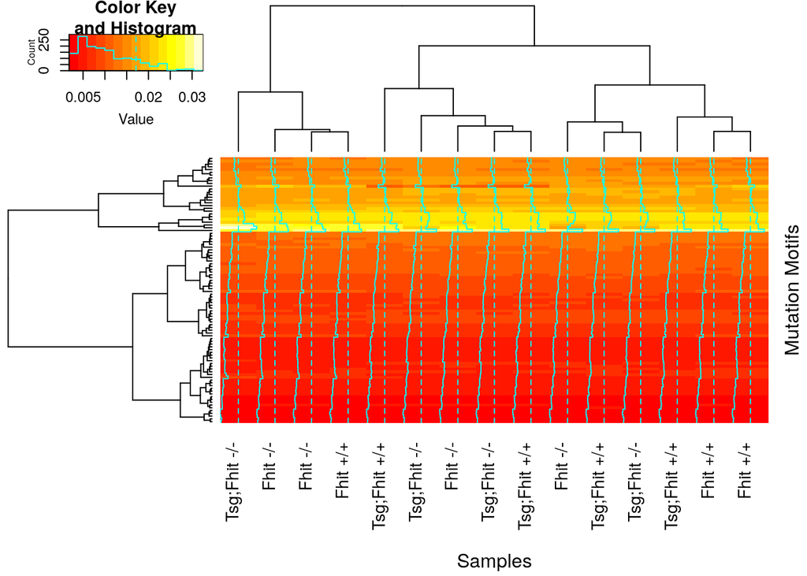

```r
mm_col_genotypes <-
  sample_info %>%
  column_to_rownames("sample_id") %>%
  {.[colnames(mm), ]} %>%
  pull(Genotype)

mm %>%
  magrittr::set_colnames(mm_col_genotypes) %>%
  gplots::heatmap.2(
    xlab = "Samples",
    ylab = "Mutation Motifs", labRow = FALSE,
    margins = c(8, 2))
```

Samples do not appear to cluster by genotype.

### 2.1.2 Frequencies by Genotype

These are average motif frequencies in samples with each genotype.

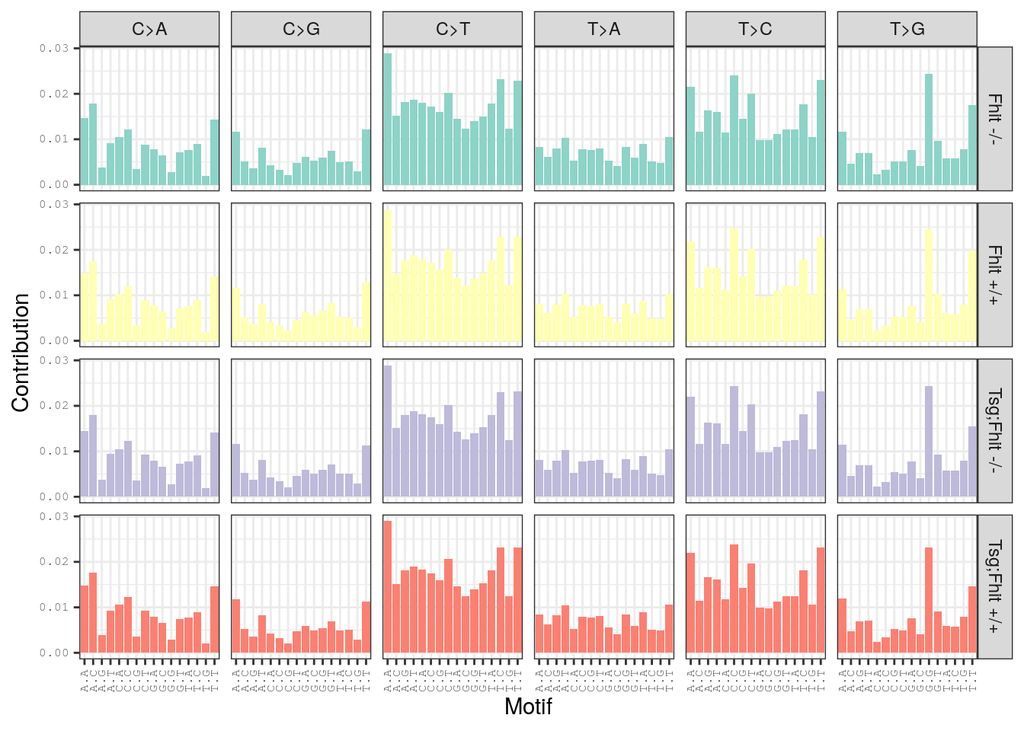

```r
plotMutationSpectrum(vr, group = "Genotype")
```

## 2.2 Motif Principal Component Analysis

We perform principal component analysis as an unbiased way to visualize sample clustering. The data is centered and scaled prior to PCA analysis.

```r
pca_fit <- pcaMethods::pca(t(mm), nPcs = nrow(t(mm)), scale = "vector", center = TRUE)
```

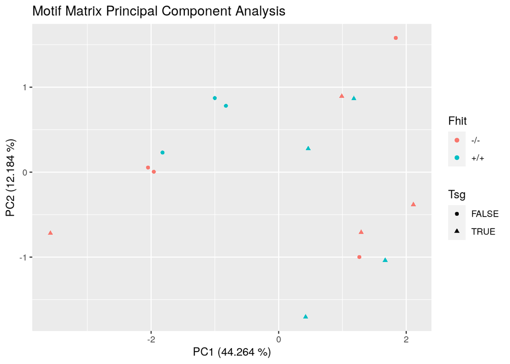

```r
pcs <- c(1,2)

pca_fit %>%
  pcaMethods::scores() %>%
  as.data.frame() %>%
  rownames_to_column("sample_id") %>%
  left_join(sample_info, by = "sample_id") %>%
  {
    ggplot(., aes_q(x = as.symbol(paste0("PC", pcs[[1]])),
                    y = as.symbol(paste0("PC", pcs[[2]])),
                    color = ~Fhit,
                    shape = ~Tsg)) +
      geom_point() +
      labs(title = "Motif Matrix Principal Component Analysis",
           x = glue("PC{pcs[[1]]} ({pca_fit@R2[[pcs[[1]]]] * 100} %)"),
           y = glue("PC{pcs[[2]]} ({pca_fit@R2[[pcs[[2]]]] * 100} %)"))
  } %>%
  # ggplotly() %>%
  {.}
```

PC1 accounts for a very large amount (44%) of mutation motif variance between samples. This PC appears to be associated with the Tsg status of the samples, but not obviously with Fhit.

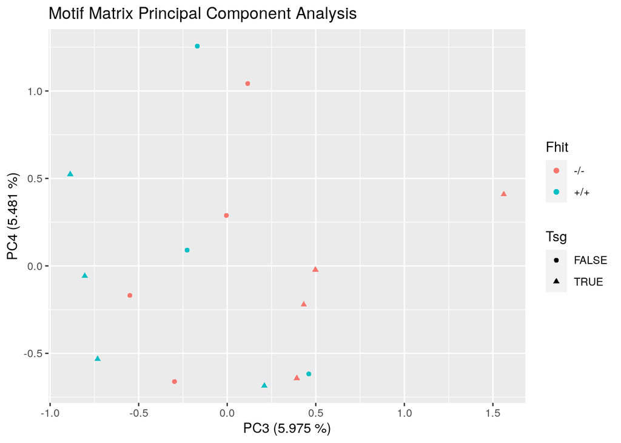

```r
pcs <- c(3,4)

pca_fit %>%
  pcaMethods::scores() %>%
  as.data.frame() %>%
  rownames_to_column("sample_id") %>%
  left_join(sample_info, by = "sample_id") %>%
  {
    ggplot(., aes_q(x = as.symbol(paste0("PC", pcs[[1]])),
                    y = as.symbol(paste0("PC", pcs[[2]])),
                    color = ~Fhit,
                    shape = ~Tsg)) +
      geom_point() +
      labs(title = "Motif Matrix Principal Component Analysis",
           x = glue("PC{pcs[[1]]} ({pca_fit@R2[[pcs[[1]]]] * 100} %)"),
           y = glue("PC{pcs[[2]]} ({pca_fit@R2[[pcs[[2]]]] * 100} %)"))
  } %>%
  # ggplotly() %>%
  {.}
```

## 2.3 Assess Number of Signatures

In order to determine the optimum number of signatures to extract, we repeat the extraction with varying numbers of signatures and examine how well each model fits.

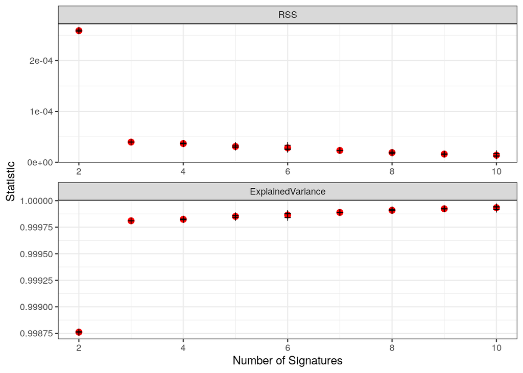

```r
n_sigs_result <- assessNumberSignatures(mm, nSigs = 2:10, nReplicates = 3)
plotNumberSignatures(n_sigs_result)
```

3 signatures appears to be an inflection point after which adding more signatures does not improve the mode fit. It is noteworthy that the scale of the Explained Variance graph starts at 0.99875, very close to a perfect fit. This appears to be a result of the homogeneity of these samples.

## 2.4 Identify Signatures

Based on the previous results we select a target of 3 signatures to extract. We use the non-negative matrix factorization method of the SomaticSignatures::identifySignatures function to perform the fit.

```r
n_sigs <- 3
sigs_nmf <- identifySignatures(mm, n_sigs, nmfDecomposition)
```

### 2.4.1 Signature Map

This plot shows relative contribution of each motif to each discovered signature.

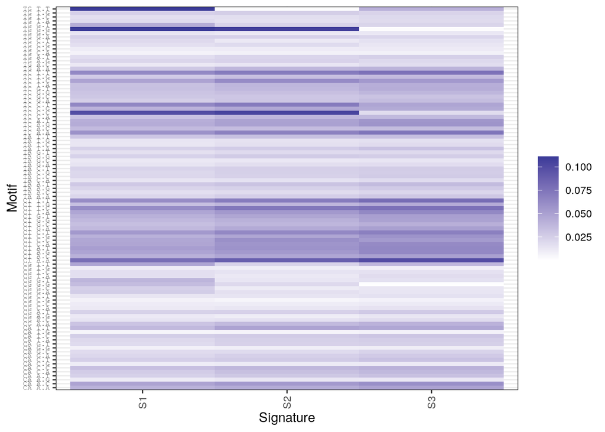

```r
plotSignatureMap(sigs_nmf)
```

### 2.4.2 Signatures

This the same information as above, but grouped by the base transition of the motif.

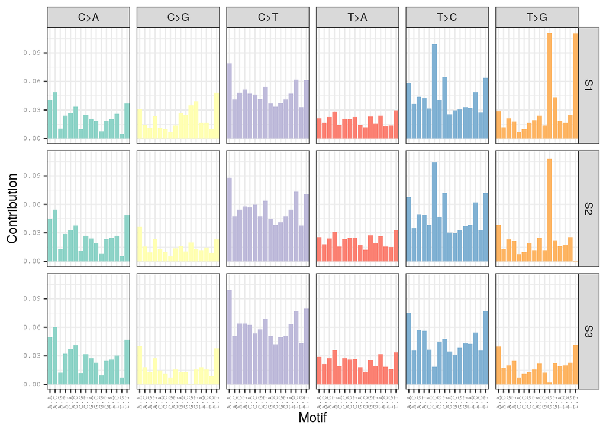

```r
plotSignatures(sigs_nmf)
```

### 2.4.3 Samples

These plots show the relative contribution of the discovered signatures to the mutational make up of each sample.

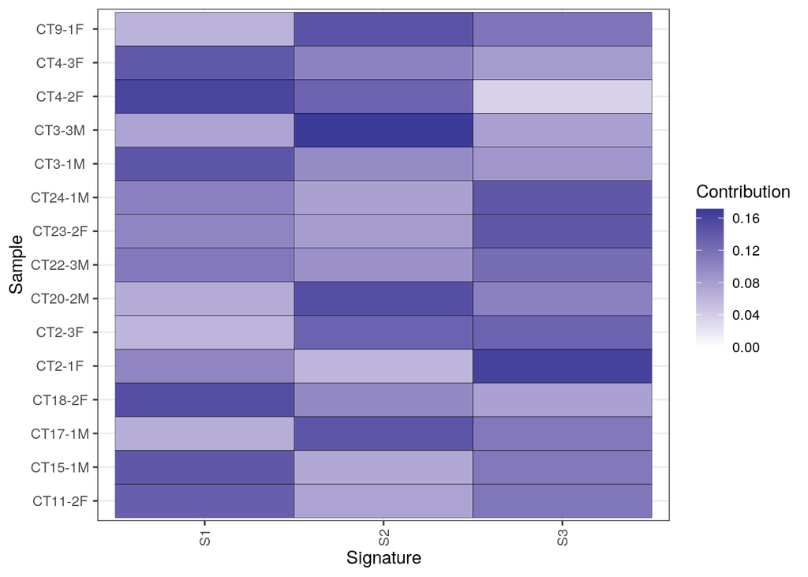

```r
plotSampleMap(sigs_nmf)
```

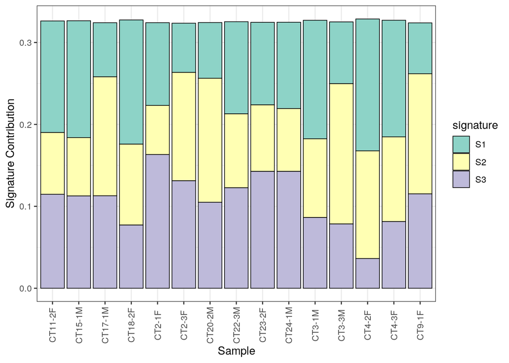

```r
plotSamples(sigs_nmf)
```

# 3 Session Info

Git Commit SHA: f8341b8f6eb6fce480a316d3dfba91c755778daf

Time Stamp: 2020-November-17 13:29:39